# EDA

Author

Anne Do - SID 541023382

```r
library(tidyverse)
library(plotly)
library(gridExtra)
theme_set(theme_bw())
```

### Loading the dataset

```r
df = read.delim("housing-prices-ge19.txt")
```

### Looking at the pattern of missing data

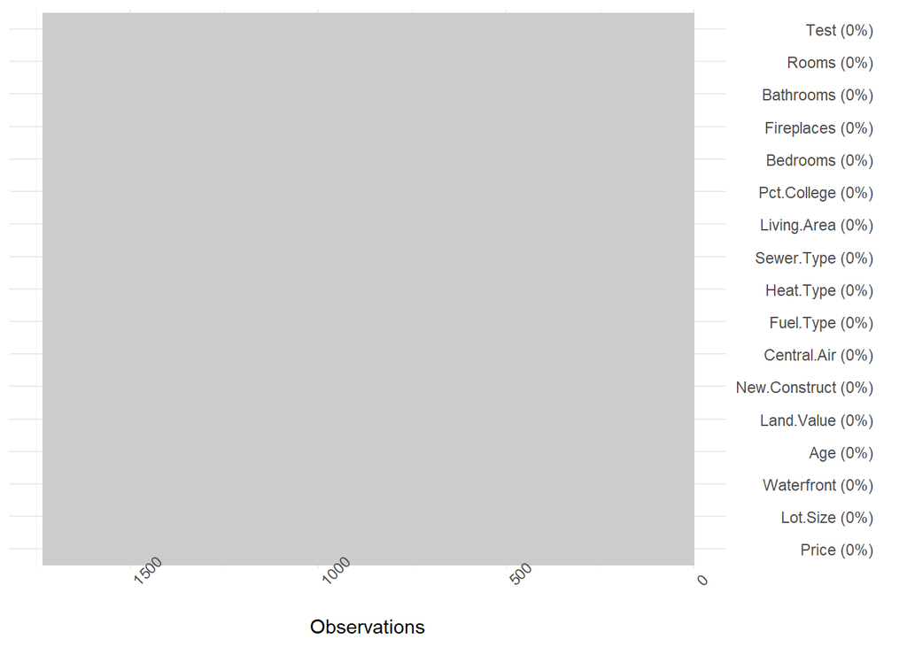

```r
visdat::vis_miss(df) + coord_flip() + theme(legend.position = "none")
```

=> No data is missing

### Data dictionary

I am using the data dictionary of the [SaratogaHouses: Houses in Saratoga County (2006) dataset](https://rdrr.io/cran/mosaicData/man/SaratogaHouses.html) (Pruim et al., 2023) to interpret the meanings and units of variables in this dataset, following the instruction from [this comment](https://edstem.org/au/courses/25836/discussion/2948658?answer=6509453) on Ed Discussion (Lauer, 2025).

### Distribution of dependent variable (house price)

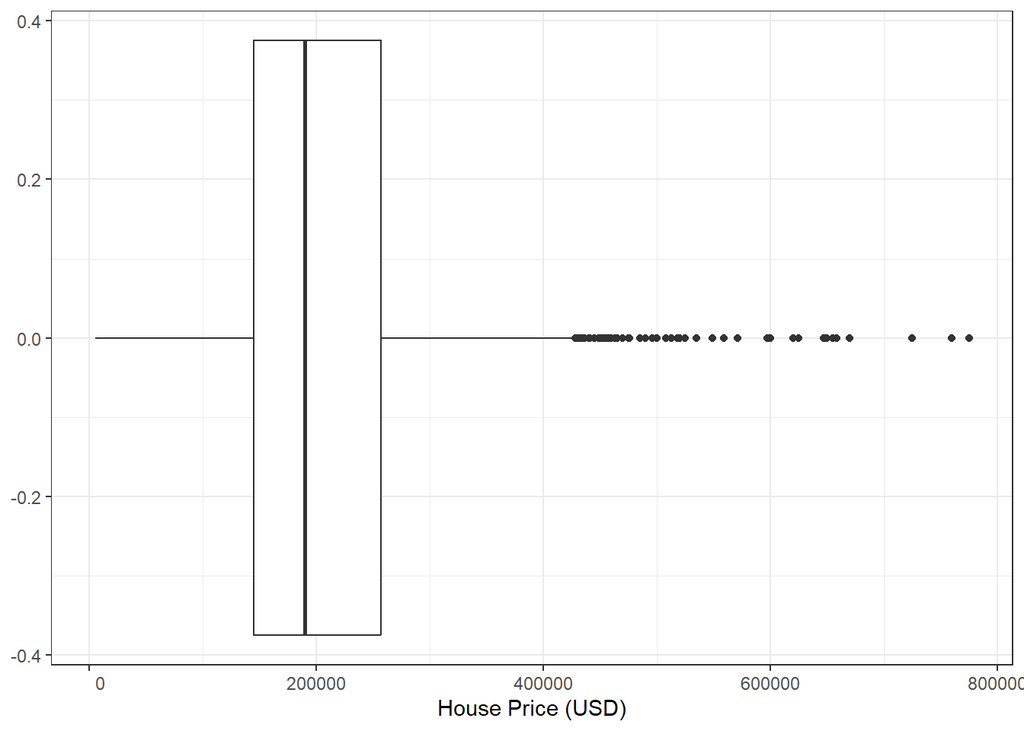

```r
Q1_Price <- quantile(df$Price, 0.25)
Q3_Price <- quantile(df$Price, 0.75)
IQR_Price <- Q3_Price - Q1_Price
lower_bound_Price <- Q1_Price - 1.5 * IQR_Price
upper_bound_Price <- Q3_Price + 1.5 * IQR_Price

ggplot(df, aes(x=Price)) +
  geom_boxplot() +
  labs(x = "House Price (USD)") +
  scale_x_continuous(labels = function(x) format(x, scientific = FALSE))
```

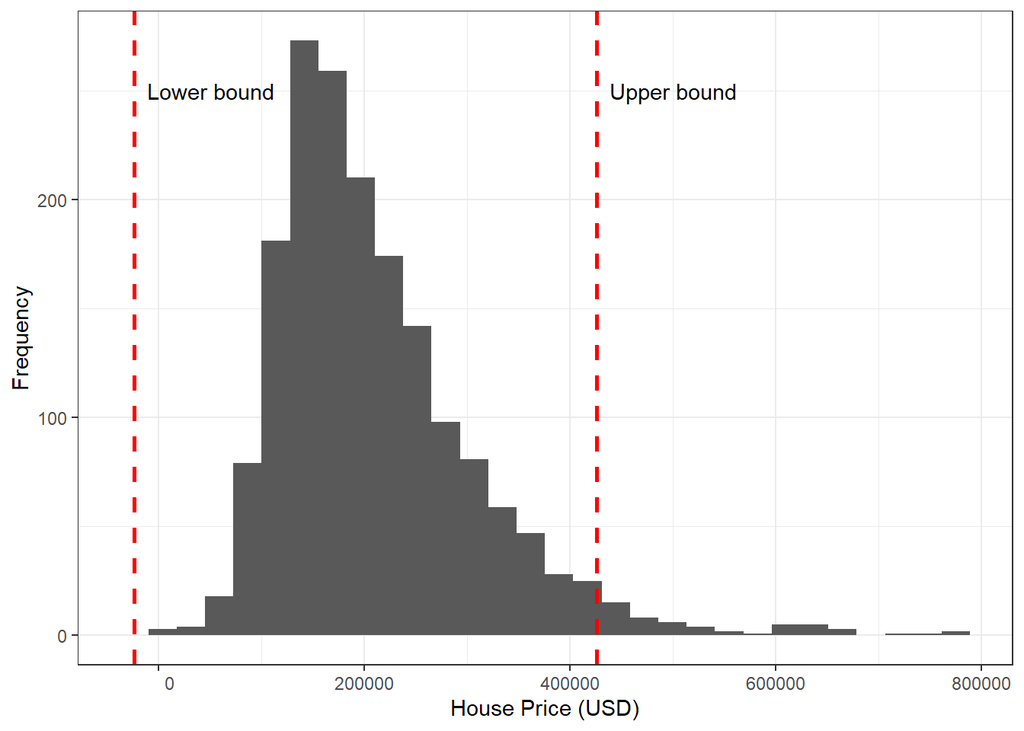

```r
ggplot(df, aes(x=Price)) +
  geom_histogram() +
  labs(x = "House Price (USD)",
       y = "Frequency") +
  scale_x_continuous(labels = function(x) format(x, scientific = FALSE))  +
  geom_vline(xintercept = lower_bound_Price, color = "red", linetype = "dashed", linewidth = 1) +
    annotate("text", x = lower_bound_Price + 75000, y = 250, label = paste0("Lower bound"))  +
  geom_vline(xintercept = upper_bound_Price, color = "red", linetype = "dashed", linewidth = 1) +
    annotate("text", x = upper_bound_Price + 75000, y = 250, label = paste0("Upper bound"))
```

```r
# ggplot(df, aes(x=Price,
#           y = after_stat(density))) +
#       geom_histogram() +
#       labs(x = "House Price",
#            y = "Probability") +
#   scale_x_continuous(labels = function(x) format(x, scientific = FALSE)) +
#   scale_y_continuous(labels = function(x) format(x, scientific = FALSE))  +
#   geom_vline(xintercept = lower_bound_Price, color = "red", linetype = "dashed", linewidth = 1)  +
#   geom_vline(xintercept = upper_bound_Price, color = "red", linetype = "dashed", linewidth = 1)

      # theme(axis.title.x = element_text(face = "bold", size = 14,
      #                                   margin = margin(t = 15)),
      #       axis.title.y = element_text(face = "bold", size = 14,
      #                                   margin = margin(r = 15)),
      #       axis.text = element_text(face = "bold", size = 12)))
```

=> Right-skewed distribution

### Reclassification to factor variables

```r
categorical_vars = c("Fuel.Type", "Heat.Type", "Sewer.Type")
df <- df %>%
  mutate(across(all_of(unname(categorical_vars)), as.factor))

# Boolean variables
boolean_vars = c("Waterfront", "New.Construct", "Central.Air")
df <- df %>%
  mutate(across(all_of(unname(boolean_vars)), as.factor))
```

### Dependent variable against potential predictors

Included in EDA submission

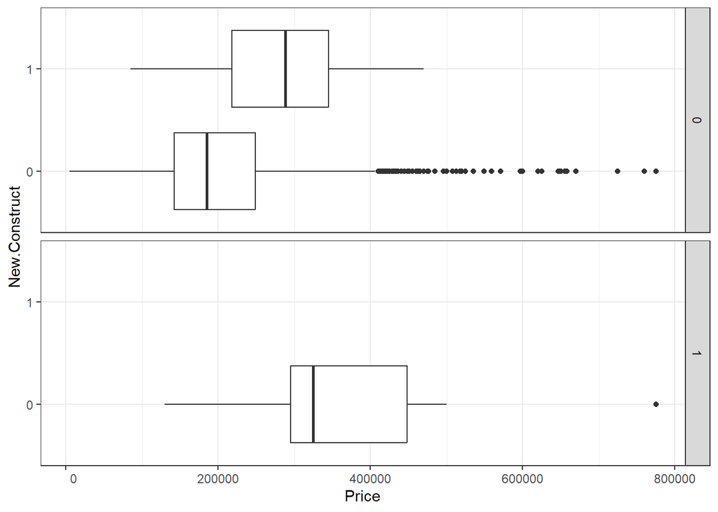

```r
ggplot(df) + aes(y = New.Construct, x = Price) +
  geom_boxplot() +
  scale_x_continuous(labels = function(x) format(x, scientific = FALSE)) +
  facet_grid( Waterfront ~ .)
```

### Dependent variable against other independent variables

#### Price vs Age

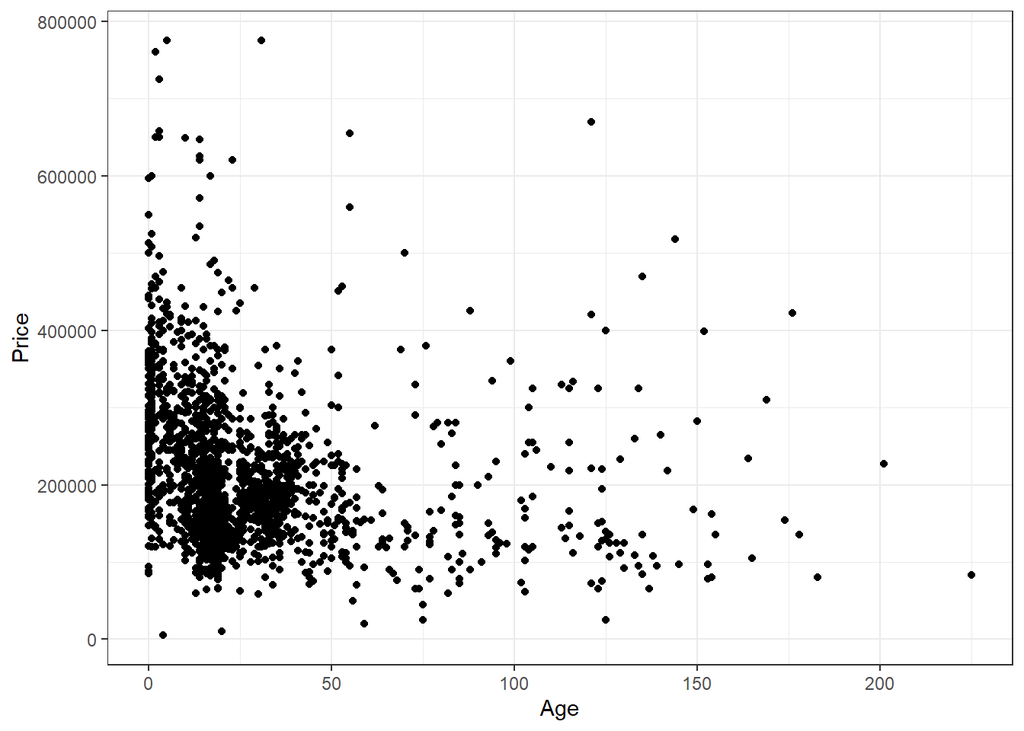

```r
ggplot(df, aes(x = Age, y = Price)) +
  geom_point() +
  scale_y_continuous(labels = function(x) format(x, scientific = FALSE))
```

=> Not normal or linear => Might need to put into graph/table with another categorical factor to see what happens

#### Price vs Lot.Size

Remove outliers from Lot.Size

```r
ggplotly(ggplot(df, aes(y=Lot.Size)) +
  geom_boxplot() +
  scale_x_continuous(labels = function(x) format(x, scientific = FALSE)))
```

[interactive chart not shown]

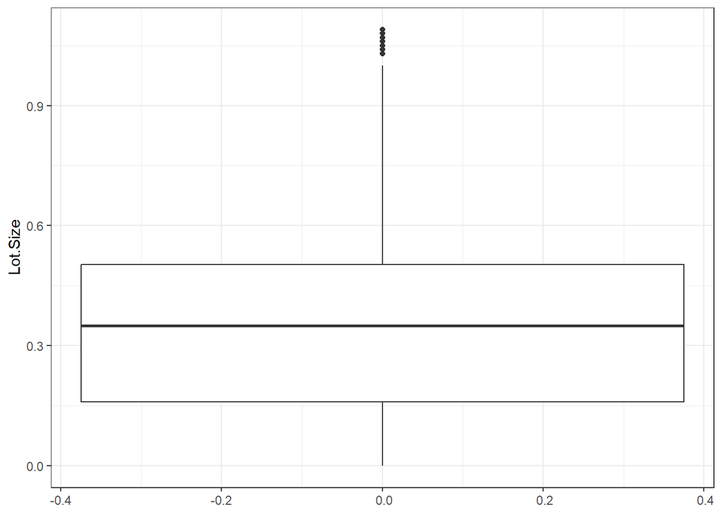

```r
Q1_LotSize <- quantile(df$Lot.Size, 0.25)
Q3_LotSize <- quantile(df$Lot.Size, 0.75)
IQR_LotSize <- Q3_LotSize - Q1_LotSize
lower_bound_LotSize <- Q1_LotSize - 1.5 * IQR_LotSize
upper_bound_LotSize <- Q3_LotSize + 1.5 * IQR_LotSize

cleaned_df_LotSize <- df %>%
  filter(Lot.Size >= lower_bound_LotSize & Lot.Size <= upper_bound_LotSize)

ggplot(cleaned_df_LotSize, aes(y=Lot.Size)) +
  geom_boxplot() +
  scale_x_continuous(labels = function(x) format(x, scientific = FALSE))
```

Visualise Price vs Lot.Size

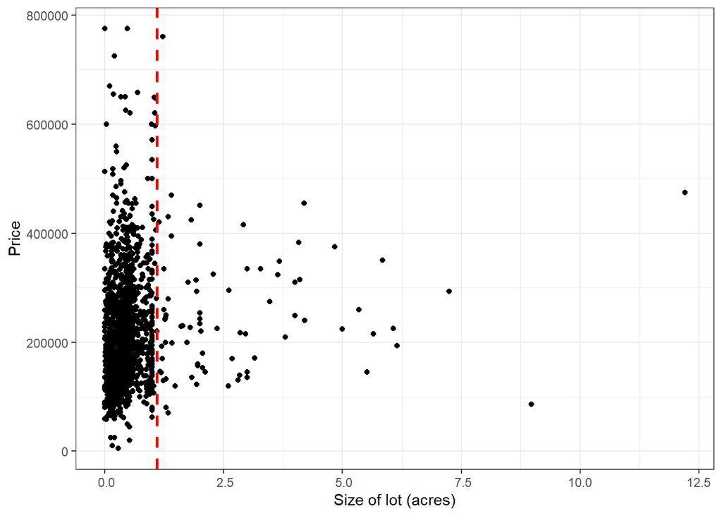

```r
ggplot(df, aes(x=Lot.Size, y = Price)) +
      geom_point() +
      labs(x = "Size of lot (acres)",
           y = "Price") +
  scale_x_continuous(labels = function(x) format(x, scientific = FALSE)) +
  scale_y_continuous(labels = function(x) format(x, scientific = FALSE))  +
  geom_vline(xintercept = upper_bound_LotSize, color = "red", linetype = "dashed", linewidth = 1)
```

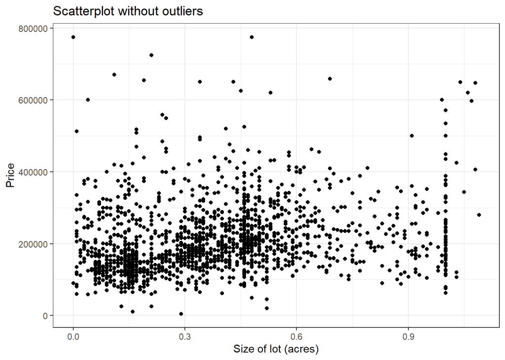

```r
ggplot(cleaned_df_LotSize, aes(x=Lot.Size, y = Price)) +
      geom_point() +
      labs(title = "Scatterplot without outliers",
           x = "Size of lot (acres)",
           y = "Price") +
  scale_x_continuous(labels = function(x) format(x, scientific = FALSE)) +
  scale_y_continuous(labels = function(x) format(x, scientific = FALSE))
```

With outlier: pretty hard to see any pattern. Without outlier: looks pretty random.

#### Price vs Land.Value

Distribution of Land.Value

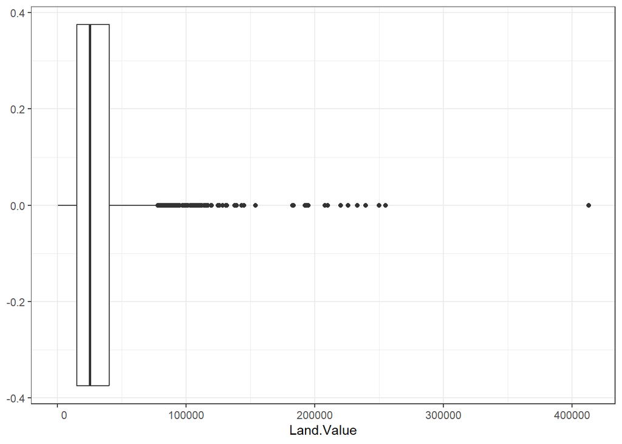

```r
ggplot(df, aes(x = Land.Value)) +
  geom_boxplot() +
  scale_x_continuous(labels = function(x) format(x, scientific = FALSE))
```

```r
Q1_LandVal <- quantile(df$Land.Value, 0.25)
Q3_LandVal <- quantile(df$Land.Value, 0.75)
IQR_LandVal <- Q3_LandVal - Q1_LandVal
lower_bound_LandVal <- Q1_LandVal - 1.5 * IQR_LandVal
upper_bound_LandVal <- Q3_LandVal + 1.5 * IQR_LandVal
```

Scatterplot of Price against Land.Value

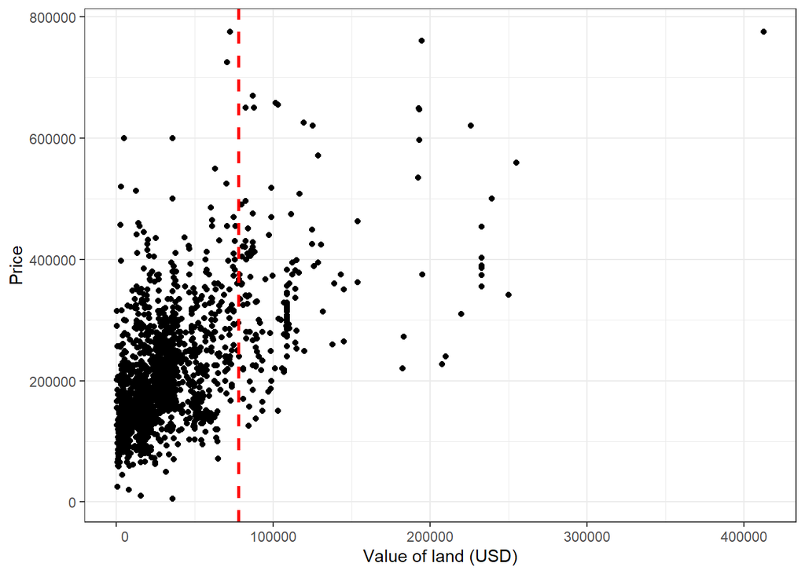

```r
ggplot(df, aes(x=Land.Value, y = Price)) +
      geom_point() +
      labs(x = "Value of land (USD)",
           y = "Price") +
  geom_vline(xintercept = upper_bound_LandVal, color = "red", linetype = "dashed", linewidth = 1) +
  scale_x_continuous(labels = function(x) format(x, scientific = FALSE)) +
  scale_y_continuous(labels = function(x) format(x, scientific = FALSE))
```

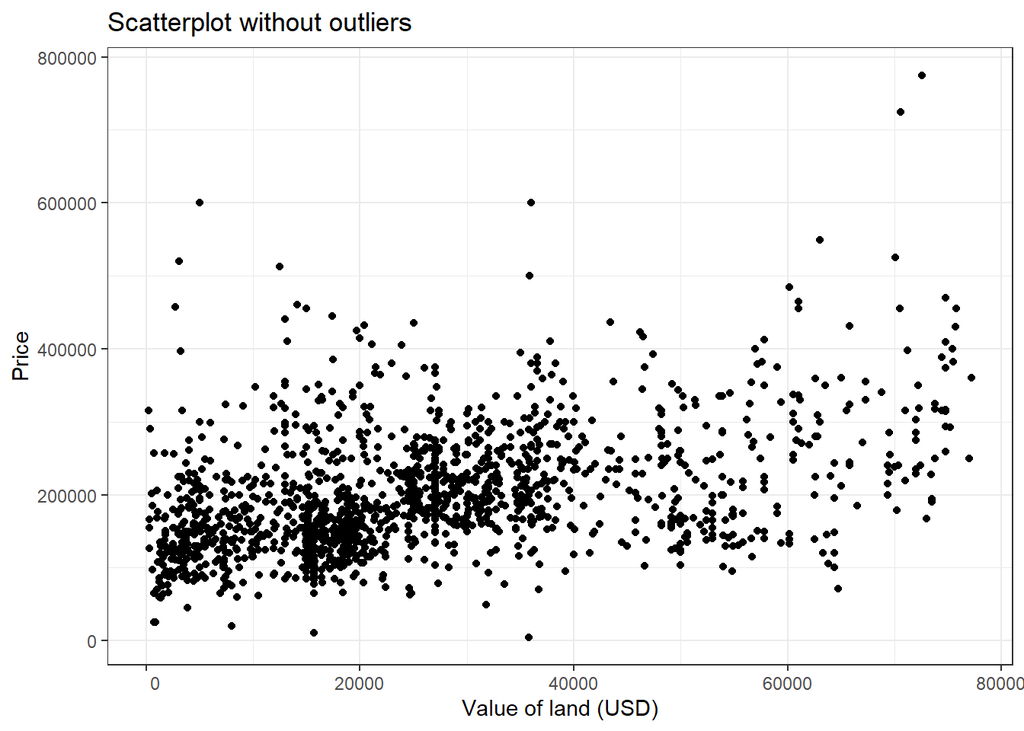

```r
df %>%
  filter(Land.Value >= lower_bound_LandVal & Land.Value <= upper_bound_LandVal) %>%
  ggplot(aes(x=Land.Value, y = Price)) +
  geom_point() +
  labs(title = "Scatterplot without outliers",
       x = "Value of land (USD)",
       y = "Price") +
  scale_x_continuous(labels = function(x) format(x, scientific = FALSE)) +
  scale_y_continuous(labels = function(x) format(x, scientific = FALSE))
```

May fit linear model

#### Price vs Living.Area

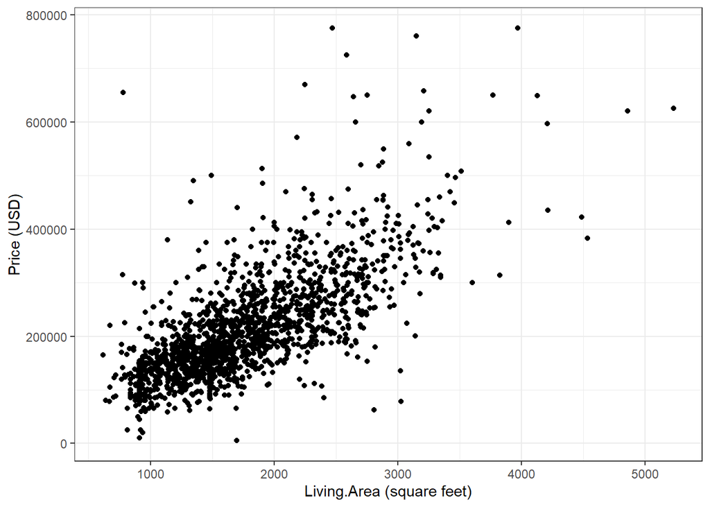

```r
ggplot(df, aes(x=Living.Area, y = Price)) +
      geom_point() +
      labs(x = "Living.Area (square feet)",
           y = "Price (USD)") +
  scale_x_continuous(labels = function(x) format(x, scientific = FALSE)) +
  scale_y_continuous(labels = function(x) format(x, scientific = FALSE))
```

#### Price vs Pct.College

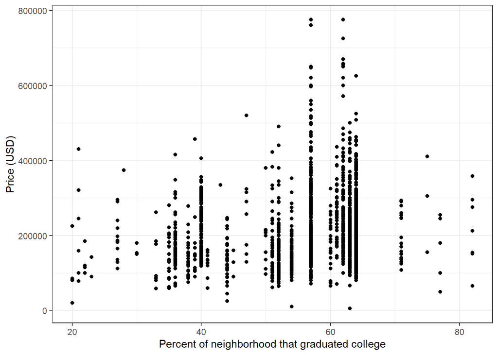

```r
ggplot(df, aes(x=Pct.College, y = Price)) +
      geom_point() +
      labs(x = "Percent of neighborhood that graduated college",
           y = "Price (USD)") +
  scale_x_continuous(labels = function(x) format(x, scientific = FALSE)) +
  scale_y_continuous(labels = function(x) format(x, scientific = FALSE))
```

Maybe easier to visualise if we group percentages into groups

#### Price vs Bedrooms

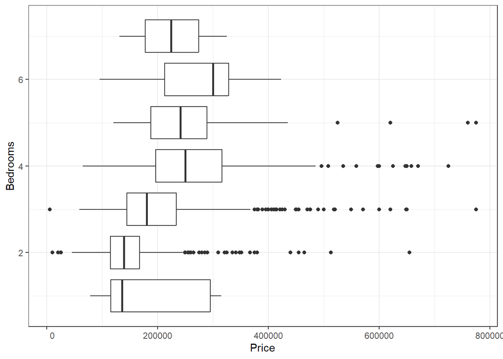

```r
ggplot(df, aes(x = Price, y = Bedrooms, group=Bedrooms)) +
  geom_boxplot() +
  scale_x_continuous(labels = function(x) format(x, scientific = FALSE))
```

Does impact/ Does have a relation => Needs testing/ investigation

Mean of house price of house with:

- 1 bedroom: 1.9277143^{5}
- 2 bedrooms: 1.5187145^{5} -> Decrease
- 3 bedrooms: 2.0040118^{5} -> Increase, close to that of 1 bedroom

Quite similar:

- 4 bedrooms: 2.6555064^{5}
- 5 bedrooms: 2.7657755^{5}
- 6 bedrooms: 2.7732875^{5}

Decrease:

- 7 bedrooms: 2.2666667^{5}

#### Price vs Fireplaces

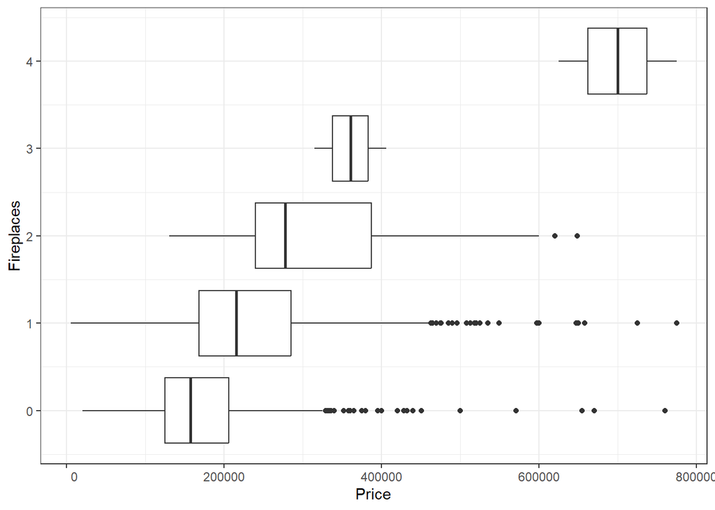

```r
ggplot(df, aes(x = Price, y = Fireplaces, group=Fireplaces)) +
  geom_boxplot() +
  scale_x_continuous(labels = function(x) format(x, scientific = FALSE))
```

Seems to have an impact: Mean increasing

```r
# Increases all the way
mean(df$Price[df$Fireplaces == 0])
```

```
[1] 173973.4
```

```r
mean(df$Price[df$Fireplaces == 1])
```

```
[1] 235162.9
```

```r
mean(df$Price[df$Fireplaces == 2])
```

```
[1] 318821.4
```

```r
mean(df$Price[df$Fireplaces == 3])
```

```
[1] 360500
```

```r
mean(df$Price[df$Fireplaces == 4])
```

```
[1] 7e+05
```

#### Price vs Bathrooms

```r
table(df$Bathrooms)
```

```
  0   1 1.5   2 2.5   3 3.5   4 4.5
  1 328 498 257 549  56  36   8   1
```

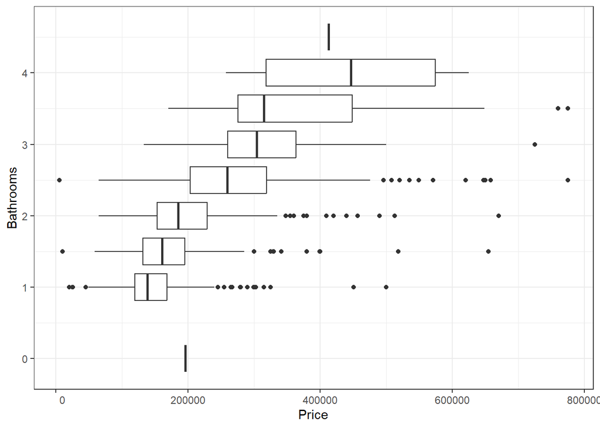

```r
ggplot(df, aes(x = Price, y = Bathrooms, group=Bathrooms)) +
  geom_boxplot() +
  scale_x_continuous(labels = function(x) format(x, scientific = FALSE))
```

0 and 4.5 pretty hard but for others: increase

```r
print("0 bathroom")
```

```
[1] "0 bathroom"
```

```r
mean(df$Price[df$Bathrooms == 0])
```

```
[1] 195900
```

```r
print("1 bathroom")
```

```
[1] "1 bathroom"
```

```r
mean(df$Price[df$Bathrooms == 1])
```

```
[1] 147378.6
```

```r
print("1.5 bathrooms")
```

```
[1] "1.5 bathrooms"
```

```r
mean(df$Price[df$Bathrooms == 1.5])
```

```
[1] 167946.7
```

```r
print("2 bathrooms")
```

```
[1] "2 bathrooms"
```

```r
mean(df$Price[df$Bathrooms == 2])
```

```
[1] 200612.4
```

```r
print("2.5 bathrooms")
```

```
[1] "2.5 bathrooms"
```

```r
mean(df$Price[df$Bathrooms == 2.5])
```

```
[1] 268344.7
```

```r
print("3 bathrooms")
```

```
[1] "3 bathrooms"
```

```r
mean(df$Price[df$Bathrooms == 3])
```

```
[1] 320978.7
```

```r
print("3.5 bathrooms")
```

```
[1] "3.5 bathrooms"
```

```r
mean(df$Price[df$Bathrooms == 3.5])
```

```
[1] 383112.9
```

```r
print("4 bathrooms")
```

```
[1] "4 bathrooms"
```

```r
mean(df$Price[df$Bathrooms == 4])
```

```
[1] 448450.1
```

```r
print("4.5 bathrooms")
```

```
[1] "4.5 bathrooms"
```

```r
mean(df$Price[df$Bathrooms == 4.5])
```

```
[1] 412500
```

#### Price vs Rooms

```r
print("Summary table")
```

```
[1] "Summary table"
```

```r
table(df$Rooms)
```

```
  2   3   4   5   6   7   8   9  10  11  12
  2  80 185 225 247 305 258 142 141  72  77
```

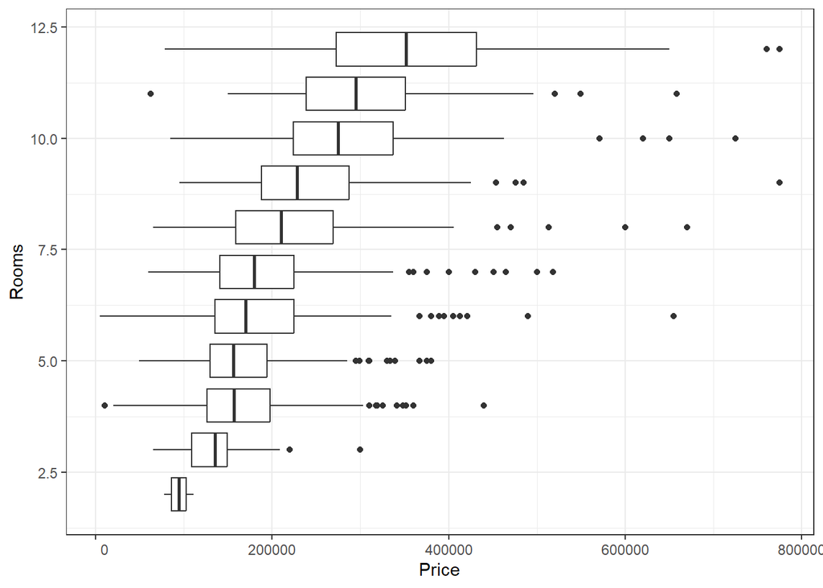

```r
ggplot(df, aes(x = Price, y = Rooms, group=Rooms)) +
  geom_boxplot() +
  scale_x_continuous(labels = function(x) format(x, scientific = FALSE))
```

Does matter? Have a table with all types of room

```r
# Has tendency to increase
print("Mean value of each number of rooms (ascending)")
```

```
[1] "Mean value of each number of rooms (ascending)"
```

```r
mean(df$Price[df$Rooms == 2])
```

```
[1] 94500
```

```r
mean(df$Price[df$Rooms == 3])
```

```
[1] 134156.2
```

```r
mean(df$Price[df$Rooms == 4])
```

```
[1] 167251.6
```

```r
mean(df$Price[df$Rooms == 5])
```

```
[1] 166580.4
```

```r
mean(df$Price[df$Rooms == 6])
```

```
[1] 185313.7
```

```r
mean(df$Price[df$Rooms == 7])
```

```
[1] 191829
```

```r
mean(df$Price[df$Rooms == 8])
```

```
[1] 220596.8
```

```r
mean(df$Price[df$Rooms == 9])
```

```
[1] 245278.8
```

```r
mean(df$Price[df$Rooms == 10])
```

```
[1] 288567.2
```

```r
mean(df$Price[df$Rooms == 11])
```

```
[1] 305913.7
```

```r
mean(df$Price[df$Rooms == 12])
```

```
[1] 373218.8
```

=> Has tendency to increase.

#### Price vs Fuel.Type

```r
print("Summary table")
```

```
[1] "Summary table"
```

```r
table(df$Fuel.Type)
```

```
     Electric           Gas          None           Oil         Solar
          315          1197             3           216             1
Unknown/Other          Wood
            1             1
```

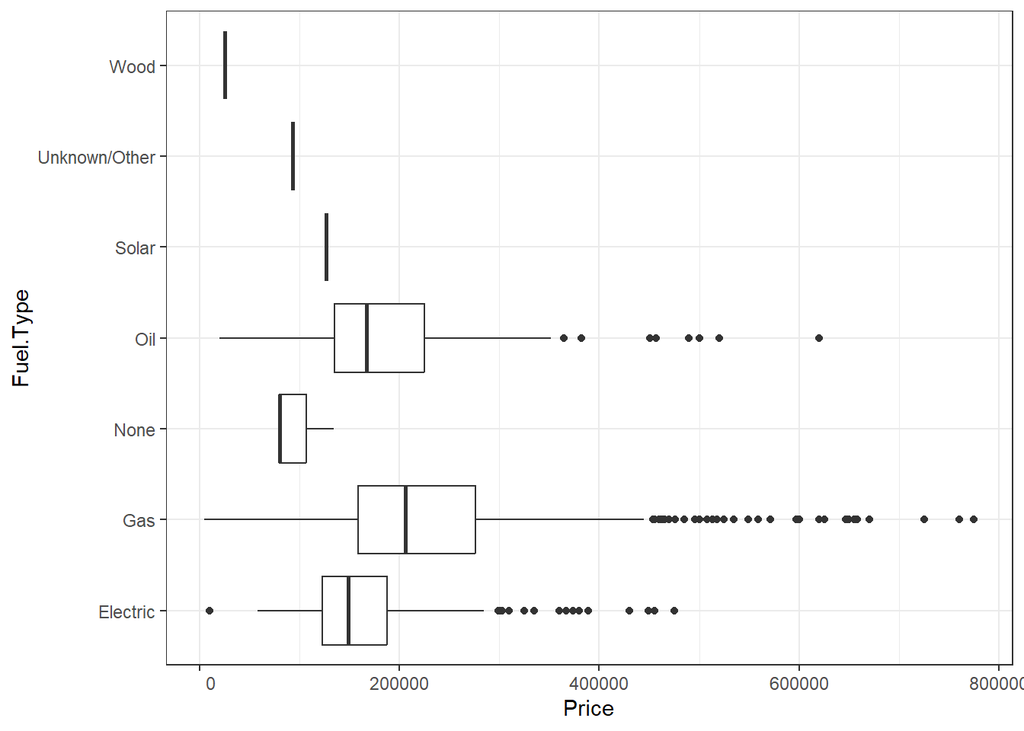

```r
ggplot(df, aes(x = Price, y = Fuel.Type)) +
  geom_boxplot() +
  scale_x_continuous(labels = function(x) format(x, scientific = FALSE))
```

=> Might has some relation?

#### Price vs Heat.Type

```r
print("Summary table")
```

```
[1] "Summary table"
```

```r
table(df$Heat.Type)
```

```
 Electric   Hot Air Hot Water      None
      305      1121       302         6
```

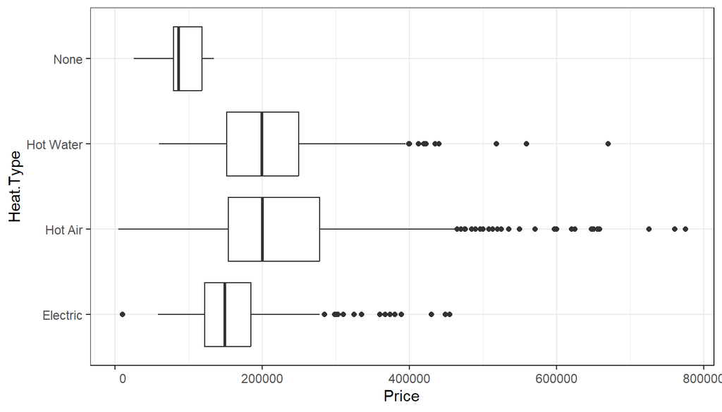

```r
ggplot(df, aes(x = Price, y = Heat.Type)) +
  geom_boxplot() +
  scale_x_continuous(labels = function(x) format(x, scientific = FALSE))
```

```r
  # facet_grid()
```

=> Maybe some relation

#### Price vs Sewer.Type

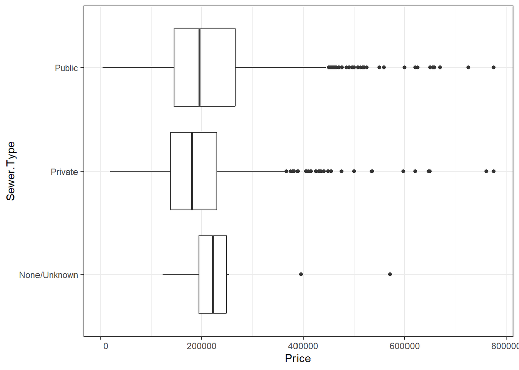

```r
ggplot(df, aes(x=Price, y=Sewer.Type, group=Sewer.Type)) +
  geom_boxplot() +
  scale_x_continuous(labels = function(x) format(x, scientific = FALSE))
```

Not super significant variation => no relation?

```r
print("Public")
```

```
[1] "Public"
```

```r
mean(df$Price[df$Sewer.Type == "Public"])
```

```
[1] 216284.8
```

```r
print("Private")
```

```
[1] "Private"
```

```r
mean(df$Price[df$Sewer.Type == "Private"])
```

```
[1] 199253.7
```

```r
print("None/Unknown")
```

```
[1] "None/Unknown"
```

```r
mean(df$Price[df$Sewer.Type == "None/Unknown"])
```

```
[1] 250952.3
```

#### Price vs Waterfront

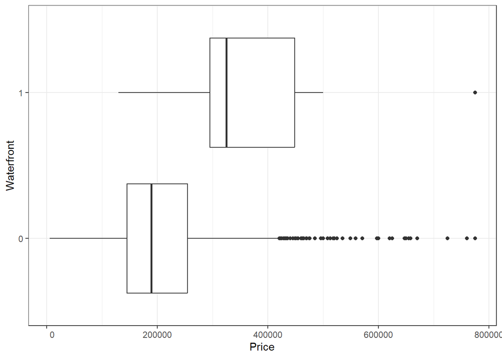

```r
ggplot(df, aes(x=Price, y=Waterfront, group=Waterfront)) +
  geom_boxplot() +
  scale_x_continuous(labels = function(x) format(x, scientific = FALSE))
```

=> There is relation

```r
t.test(df$Price[df$Waterfront == 0],
       df$Price[df$Waterfront == 1],
       var.equal=F)
```

```
    Welch Two Sample t-test

data:  df$Price[df$Waterfront == 0] and df$Price[df$Waterfront == 1]
t = -4.0866, df = 14.095, p-value = 0.001096
alternative hypothesis: true difference in means is not equal to 0
95 percent confidence interval:
 -249811.78  -77916.47
sample estimates:
mean of x mean of y
 210127.5  373991.7
```

The distributions don’t look quite normal -> Might have to take permutation test

#### Price vs New.Construct

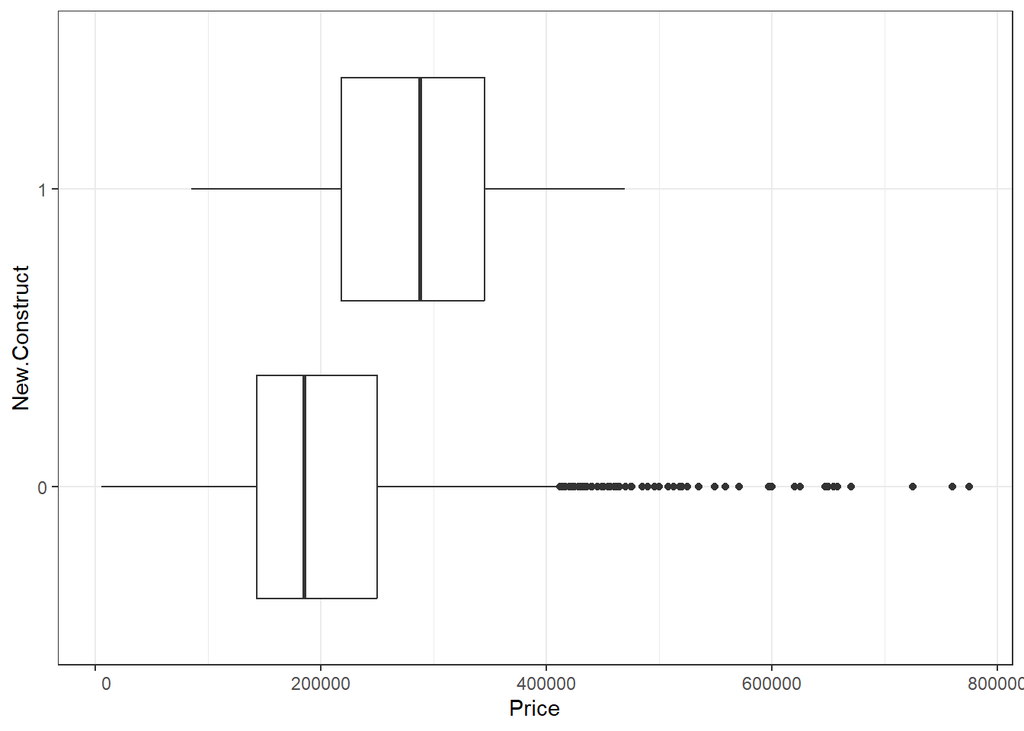

```r
ggplot(df, aes(x=Price, y=New.Construct, group=New.Construct)) +
  geom_boxplot() +
  scale_x_continuous(labels = function(x) format(x, scientific = FALSE))
```

=> Yes relation

```r
t.test(df$Price[df$New.Construct == 0],
       df$Price[df$New.Construct == 1],
       var.equal=F)
```

```
    Welch Two Sample t-test

data:  df$Price[df$New.Construct == 0] and df$Price[df$New.Construct == 1]
t = -7.7088, df = 91.017, p-value = 1.527e-11
alternative hypothesis: true difference in means is not equal to 0
95 percent confidence interval:
 -93356.30 -55102.13
sample estimates:
mean of x mean of y
 208077.6  282306.8
```

The distributions don’t look quite normal -> Might have to take permutation test

#### Price vs Central.Air

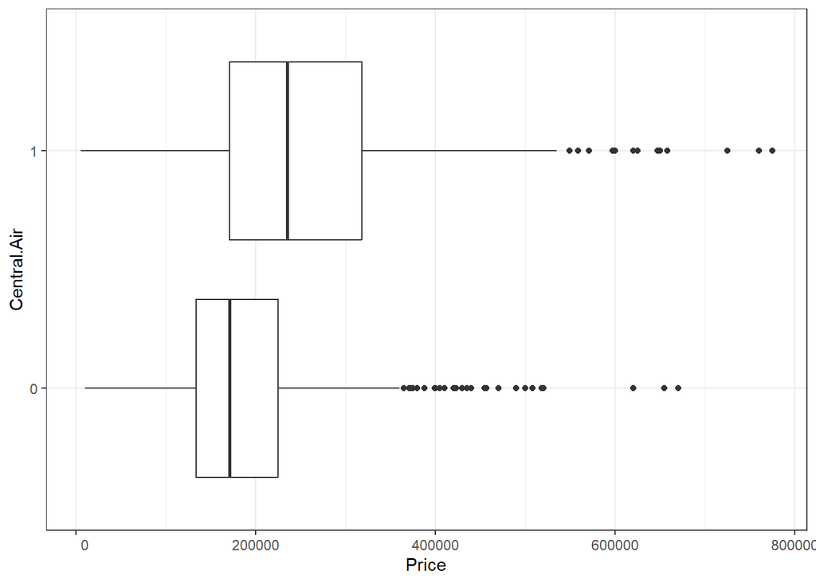

```r
ggplot(df, aes(x=Price, y=Central.Air, group=Central.Air)) +
  geom_boxplot() +
  scale_x_continuous(labels = function(x) format(x, scientific = FALSE))
```

```r
t.test(df$Price[df$Central.Air == 0],
       df$Price[df$Central.Air == 1],
       var.equal=F)
```

```
    Welch Two Sample t-test

data:  df$Price[df$Central.Air == 0] and df$Price[df$Central.Air == 1]
t = -13.426, df = 986.84, p-value < 2.2e-16
alternative hypothesis: true difference in means is not equal to 0
95 percent confidence interval:
 -78410.53 -58412.09
sample estimates:
mean of x mean of y
 186492.5  254903.8
```

The distributions don’t look quite normal -> Might have to take permutation test

#### Price vs Bathrooms and boolean

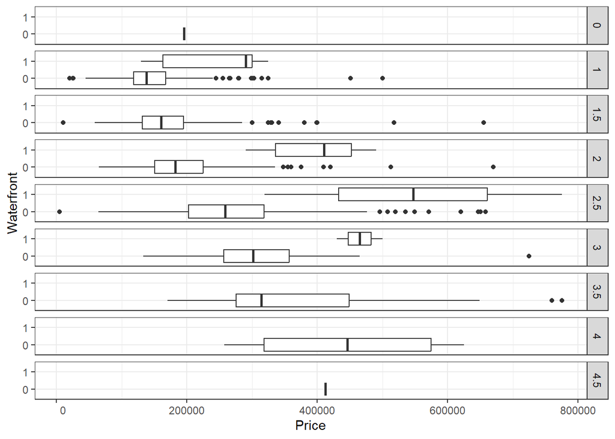

```r
ggplot(df) +
  aes(y = Waterfront, x = Price) +
  geom_boxplot() +
  scale_x_continuous(labels = function(x) format(x, scientific = FALSE)) +
  facet_grid( Bathrooms ~ .)
```

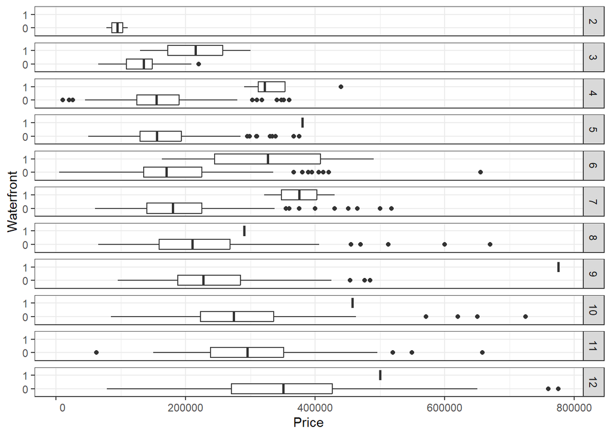

```r
ggplot(df) + aes(y = Waterfront, x = Price) +
  geom_boxplot() +
  scale_x_continuous(labels = function(x) format(x, scientific = FALSE)) +
  facet_grid( Rooms ~ .)
```

3 variables: Bathrooms ~ Heat.Type

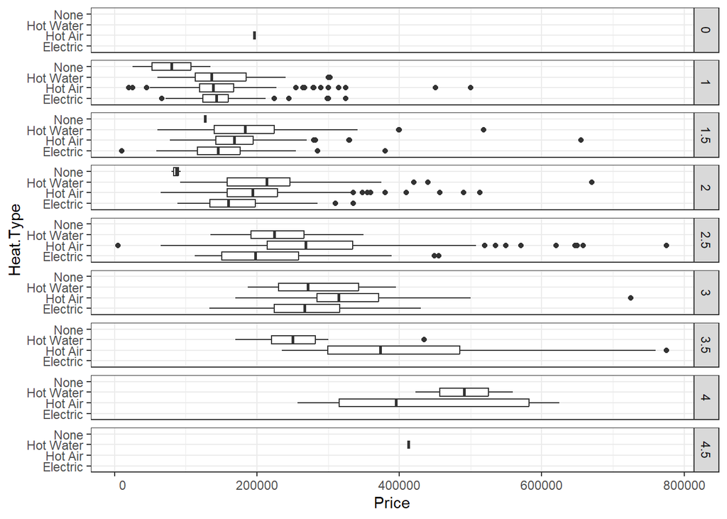

```r
ggplot(df) + aes(y = Heat.Type, x = Price) +
  geom_boxplot() +
  scale_x_continuous(labels = function(x) format(x, scientific = FALSE)) +
  facet_grid( Bathrooms ~ .)
```

3 variables: Bathrooms ~ Sewer.Type

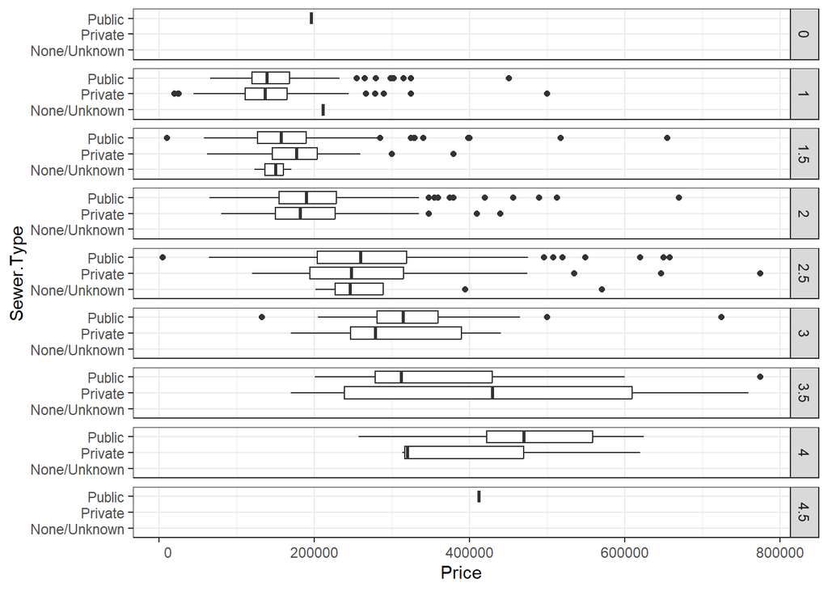

```r
ggplot(df) + aes(y = Sewer.Type, x = Price) +
  geom_boxplot() +
  scale_x_continuous(labels = function(x) format(x, scientific = FALSE)) +
  facet_grid( Bathrooms ~ .)
```

=> Too hard to view

3 variables: Heat.Type ~ Sewer.Type

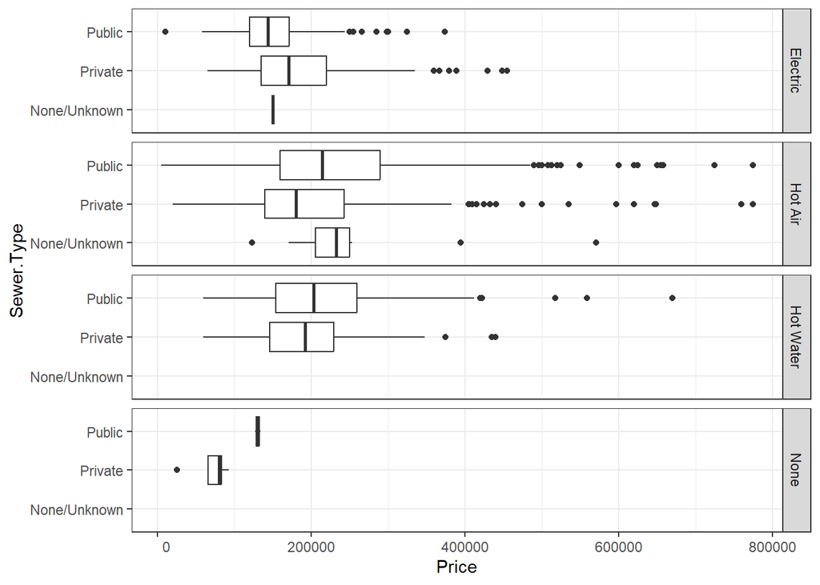

```r
ggplot(df) + aes(y = Sewer.Type, x = Price) +
  geom_boxplot() +
  scale_x_continuous(labels = function(x) format(x, scientific = FALSE)) +
  facet_grid( Heat.Type ~ .)
```

=> I don’t know what I can conclude out of that

3 variable: New.Construct, Central.Air

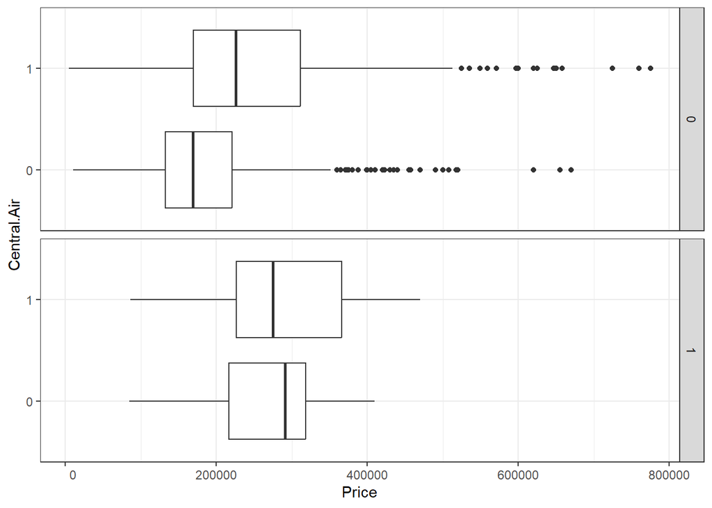

```r
ggplot(df) + aes(y = Central.Air, x = Price) +
  geom_boxplot() +
  scale_x_continuous(labels = function(x) format(x, scientific = FALSE)) +
  facet_grid( New.Construct ~ .)
```

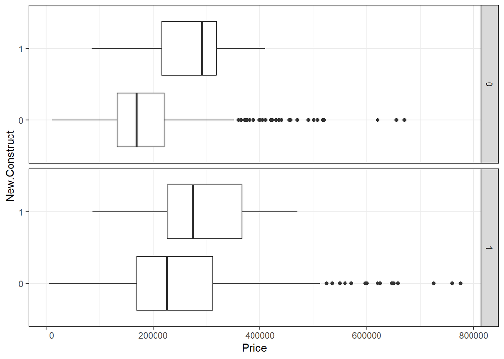

```r
ggplot(df) + aes(y = New.Construct, x = Price) +
  geom_boxplot() +
  scale_x_continuous(labels = function(x) format(x, scientific = FALSE)) +
  facet_grid( Central.Air ~ .)
```

Median between yes and no Central.Air pretty similar when newly constructed

```r
mean(df$Price[df$New.Construct == 0 & df$Central.Air == 0])
```

```
[1] 183545.8
```

```r
mean(df$Price[df$New.Construct == 1 & df$Central.Air == 0])
```

```
[1] 268766.8
```

```r
mean(df$Price[df$New.Construct == 0 & df$Central.Air == 1])
```

```
[1] 252044.2
```